# Mapping NYC’s Urban Forest

A Spatial Analysis of Street Trees Across City Council Districts

Author

Mirae Han

Published

Invalid Date

# Introduction

## Urban Trees and Environmental Justice

New York City’s urban forest represents one of the most valuable environmental assets for the five boroughs. With over 680,000 street trees catalogued in the 2015 Street Tree Census, these living infrastructure components provide critical ecosystem services including air quality improvement, stormwater management, urban heat island mitigation, and enhanced quality of life for residents.

However, the distribution of these environmental benefits is far from uniform. Understanding which neighborhoods and council districts have robust tree canopy coverage—and which face tree deserts—has important implications for environmental justice and urban planning policy.

## Research Questions

This analysis examines NYC’s street tree distribution across City Council districts to answer five key questions:

1. **Which council district has the most trees?** Identifying areas with strong tree infrastructure
2. **Which district has the highest tree density?** Accounting for district size to find true tree coverage
3. **Where are trees most at risk?** Finding districts with the highest proportion of dead or dying trees
4. **What trees thrive in Manhattan?** Understanding species distribution in the urban core
5. **What’s nearest to Baruch College?** A hyperlocal exploration of campus tree diversity

## Data Sources

**NYC Street Tree Census (2015)**  
- Source: NYC Parks Department via NYC Open Data Portal  
- Records: ~680,000+ street trees  
- Attributes: Species, health condition, location coordinates, tree dimensions

**NYC City Council District Boundaries**  
- Source: NYC Department of City Planning  
- 51 council districts across five boroughs  
- Includes district area for density calculations

# Data Acquisition

```r
# Helper function: create WGS84 point from lat/lon
new_st_point <- function(lat, lon) {
  st_sfc(st_point(c(lon, lat))) |>
    st_set_crs("WGS84")
}
```

## Task 1: Loading Council District Boundaries

```r
#' Load NYC City Council District Boundaries
get_nyc_council_districts <- function() {

  data_dir <- file.path("data", "mp03")

  # Find existing ZIP file
  zip_file <- list.files(data_dir, pattern = "\\.zip$", full.names = TRUE)

  if (length(zip_file) == 0) {
    stop("No ZIP file found in data/mp03. Please download and place it there.")
  }

  zip_file <- zip_file[1]

  # Unzip if needed
  unzip_dir <- file.path(data_dir, file_path_sans_ext(basename(zip_file)))

  if (!dir.exists(unzip_dir)) {
    unzip(zip_file, exdir = unzip_dir)
  }

  # Find and read shapefile
  shp_file <- list.files(unzip_dir, pattern = "\\.shp$",
                         full.names = TRUE, recursive = TRUE)[1]

  if (is.na(shp_file)) {
    stop("Could not find a .shp file inside the ZIP.")
  }

  # Read and transform to WGS84
  st_read(shp_file, quiet = TRUE) |>
    st_transform(crs = "WGS84")
}

# Load data
NYC_CC <- get_nyc_council_districts()

# Create simplified version for visualization
NYC_CC_SIMP <- NYC_CC |>
  mutate(geometry = st_simplify(geometry, dTolerance = 5, preserveTopology = TRUE))
```

The council district shapefile contains **51 districts** covering all five boroughs. We simplified the geometry for faster rendering while preserving topological relationships.

## Task 2: Downloading Tree Census Data

```r
#' Download NYC Street Tree Data via API
get_nyc_tree_points <- function(limit = 50000) {

  data_dir <- file.path("data", "mp03")

  base_req <- request("https://data.cityofnewyork.us") |>
    req_url_path_append("resource") |>
    req_url_path_append("hn5i-inap.geojson") |>
    req_error(is_error = \(resp) FALSE)

  offset <- 0L
  page   <- 1L
  files  <- character()

  repeat {
    fname <- file.path(data_dir,
                      glue("nyc_treepoints_{sprintf('%03d', page)}.geojson"))

    if (!file.exists(fname)) {
      resp <- base_req |>
        req_url_query(`$limit` = limit, `$offset` = offset) |>
        req_perform()

      if (resp_is_error(resp)) {
        stop("Tree points request failed with status ", resp_status(resp))
      }

      writeBin(resp_body_raw(resp), fname)
    }

    files <- c(files, fname)
    tmp <- st_read(fname, quiet = TRUE)

    if (nrow(tmp) < limit) break

    offset <- offset + limit
    page   <- page + 1L
  }

  # Combine all chunks
  map(files, ~ st_read(.x, quiet = TRUE)) |> bind_rows()
}

# Load tree dataset
NYC_TREES <- get_nyc_tree_points()
```

The API download retrieved **1,094,587** individual street tree records across NYC. Each record includes species identification, health status, and precise geographic coordinates.

# Exploratory Visualization

## Task 3: Mapping Trees and Districts

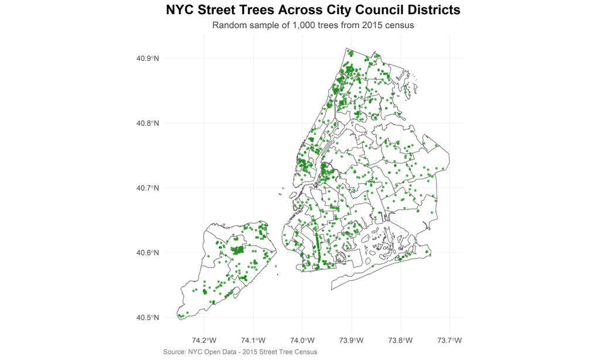

Sample of 1,000 street trees across NYC council districts

```r
# Sample trees for visualization
TREE_SAMPLE_FULL <- st_read("data/mp03/nyc_treepoints_001.geojson", quiet = TRUE)
TREE_SAMPLE <- slice_sample(TREE_SAMPLE_FULL, n = 1000)
TREE_SAMPLE <- st_transform(TREE_SAMPLE, st_crs(NYC_CC_SIMP))

# Create map
ggplot() +
  geom_sf(
    data = NYC_CC_SIMP,
    fill = NA,
    color = "grey40",
    linewidth = 0.3
  ) +
  geom_sf(
    data = TREE_SAMPLE,
    color = "forestgreen",
    alpha = 0.7,
    size = 0.8
  ) +
  coord_sf() +
  labs(
    title = "NYC Street Trees Across City Council Districts",
    subtitle = "Random sample of 1,000 trees from 2015 census",
    caption = "Source: NYC Open Data - 2015 Street Tree Census"
  ) +
  theme_minimal() +
  theme(
    plot.title = element_text(hjust = 0.5, size = 16, face = "bold"),
    plot.subtitle = element_text(hjust = 0.5, size = 11, color = "grey30"),
    plot.caption = element_text(hjust = 0, size = 8, color = "grey50"),
    axis.title = element_blank(),
    panel.grid = element_line(color = "grey90", linewidth = 0.2)
  )
```

This preliminary visualization reveals the geographic extent of NYC’s street tree inventory. Even from this small sample, we observe denser tree coverage in certain districts, particularly in outer borough neighborhoods with more residential street frontage.

# Spatial Analysis

## Task 4: Joining Trees to Districts

```r
# Ensure matching CRS
NYC_TREES <- st_transform(NYC_TREES, st_crs(NYC_CC_SIMP))

# Perform spatial join
TREE_DIST <- st_join(NYC_TREES, NYC_CC_SIMP, join = st_intersects)

# Add borough classification
TREE_DIST <- TREE_DIST |>
  mutate(
    borough = case_when(
      CounDist >= 1  & CounDist <= 10 ~ "Manhattan",
      CounDist >= 11 & CounDist <= 18 ~ "Bronx",
      CounDist >= 19 & CounDist <= 32 ~ "Queens",
      CounDist >= 33 & CounDist <= 48 ~ "Brooklyn",
      CounDist >= 49 & CounDist <= 51 ~ "Staten Island",
      TRUE ~ NA_character_
    )
  )
```

# Analysis Results

## Q1: District with Most Trees

```r
TREES_BY_DIST <- TREE_DIST |>
  st_drop_geometry() |>
  group_by(CounDist, borough) |>
  summarise(n_trees = n(), .groups = "drop") |>
  arrange(desc(n_trees))

DIST_MOST_TREES <- TREES_BY_DIST |> slice(1)

# Create table
datatable(
  head(TREES_BY_DIST, 10),
  caption = "Top 10 Council Districts by Tree Count",
  options = list(pageLength = 10, dom = 't'),
  rownames = FALSE,
  colnames = c("District", "Borough", "Number of Trees")
) |>
  formatCurrency("n_trees", currency = "", digits = 0)
```

| District | Borough | Number of Trees |
| --- | --- | --- |
| 51 | Staten Island | 70965 |
| 50 | Staten Island | 52509 |
| 19 | Queens | 49941 |
| 23 | Queens | 44949 |
| 13 | Bronx | 36659 |
| 49 | Staten Island | 35113 |
| 39 | Brooklyn | 32436 |
| 31 | Queens | 31348 |
| 32 | Queens | 30292 |
| 27 | Queens | 29365 |

**Finding:** Council District **51** in **Staten Island** leads with **70,965** street trees.

This district’s high tree count likely reflects a combination of factors including district size, residential density with tree-lined streets, and successful tree planting initiatives. Districts in the outer boroughs tend to have higher absolute tree counts due to their larger geographic areas and lower building density, which provides more street frontage for tree pits.

## Q2: Highest Tree Density

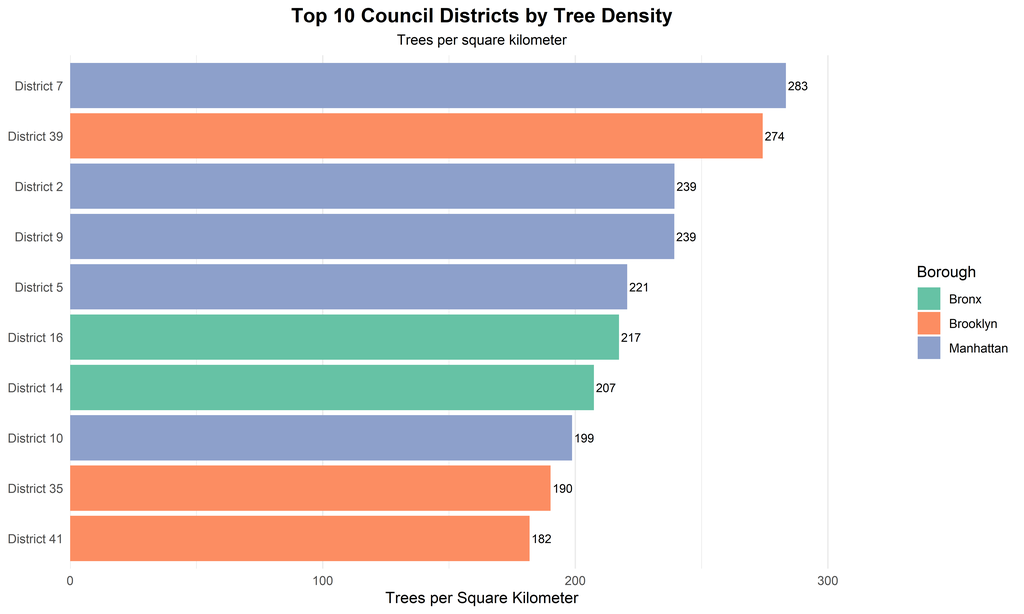

```r
TREES_DENSITY <- TREE_DIST |>
  st_drop_geometry() |>
  group_by(CounDist, borough) |>
  summarise(
    n_trees = n(),
    area = first(Shape_Area),
    .groups = "drop"
  ) |>
  mutate(
    tree_density = n_trees / area,
    trees_per_sq_km = tree_density * 1e6  # Convert to per sq km
  ) |>
  arrange(desc(tree_density))

DIST_HIGHEST_DENSITY <- TREES_DENSITY |> slice(1)

# Visualization
top10_density <- head(TREES_DENSITY, 10)

ggplot(top10_density, aes(x = reorder(paste0("District ", CounDist), trees_per_sq_km),
                          y = trees_per_sq_km, fill = borough)) +
  geom_col() +
  geom_text(aes(label = comma(round(trees_per_sq_km))),
            hjust = -0.1, size = 3) +
  coord_flip() +
  scale_y_continuous(expand = expansion(mult = c(0, 0.15))) +
  scale_fill_brewer(palette = "Set2") +
  labs(
    title = "Top 10 Council Districts by Tree Density",
    subtitle = "Trees per square kilometer",
    x = NULL,
    y = "Trees per Square Kilometer",
    fill = "Borough"
  ) +
  theme_minimal() +
  theme(
    plot.title = element_text(hjust = 0.5, size = 14, face = "bold"),
    plot.subtitle = element_text(hjust = 0.5, size = 10),
    panel.grid.major.y = element_blank()
  )
```

Unlike absolute tree count, density measures reveal which districts provide the most tree coverage relative to their size. Higher density districts often feature mature residential neighborhoods with continuous street tree planting along sidewalks, creating the characteristic tree-canopy corridors that provide maximum environmental benefits.

## Q3: Dead Tree Analysis

```r
DEAD_FRACTION <- TREE_DIST |>
  st_drop_geometry() |>
  mutate(is_dead = tpcondition == "Dead") |>
  group_by(CounDist, borough) |>
  summarise(
    n_trees = n(),
    n_dead = sum(is_dead, na.rm = TRUE),
    pct_dead = (n_dead / n_trees) * 100,
    .groups = "drop"
  ) |>
  arrange(desc(pct_dead))

DIST_HIGHEST_DEAD <- DEAD_FRACTION |> slice(1)

# Table
datatable(
  head(DEAD_FRACTION, 10),
  caption = "Districts with Highest Percentage of Dead Trees",
  options = list(pageLength = 10, dom = 't'),
  rownames = FALSE,
  colnames = c("District", "Borough", "Total Trees", "Dead Trees", "Percent Dead")
) |>
  formatCurrency(c("n_trees", "n_dead"), currency = "", digits = 0) |>
  formatRound("pct_dead", digits = 2) |>
  formatStyle(
    "pct_dead",
    background = styleColorBar(range(head(DEAD_FRACTION, 10)$pct_dead), "lightcoral"),
    backgroundSize = "90% 80%",
    backgroundRepeat = "no-repeat",
    backgroundPosition = "center"
  )
```

| District | Borough | Total Trees | Dead Trees | Percent Dead |
| --- | --- | --- | --- | --- |
| 32 | Queens | 30292 | 4316 | 14.24798626700119 |
| 30 | Queens | 23013 | 3231 | 14.03989049667579 |
| 2 | Manhattan | 11562 | 1574 | 13.61356166753157 |
| 50 | Staten Island | 52509 | 7088 | 13.49863832866747 |
| 29 | Queens | 19971 | 2688 | 13.45951629863302 |
| 16 | Bronx | 13490 | 1782 | 13.20978502594514 |
| 23 | Queens | 44949 | 5905 | 13.13711094796325 |
| 49 | Staten Island | 35113 | 4584 | 13.05499387691169 |
| 11 | Bronx | 27851 | 3626 | 13.01928117482317 |
| 20 | Queens | 20717 | 2697 | 13.01829415455906 |

**Finding:** District **32** has the highest proportion of dead trees at **14.25%**.

High dead-tree percentages can indicate several challenges including inadequate maintenance resources, harsh growing conditions (pollution, salt, compacted soil), recent pest or disease outbreaks, or insufficient replacement cycles. These districts may benefit from targeted tree care programs and expedited replacement planting.

## Q4: Manhattan’s Tree Species

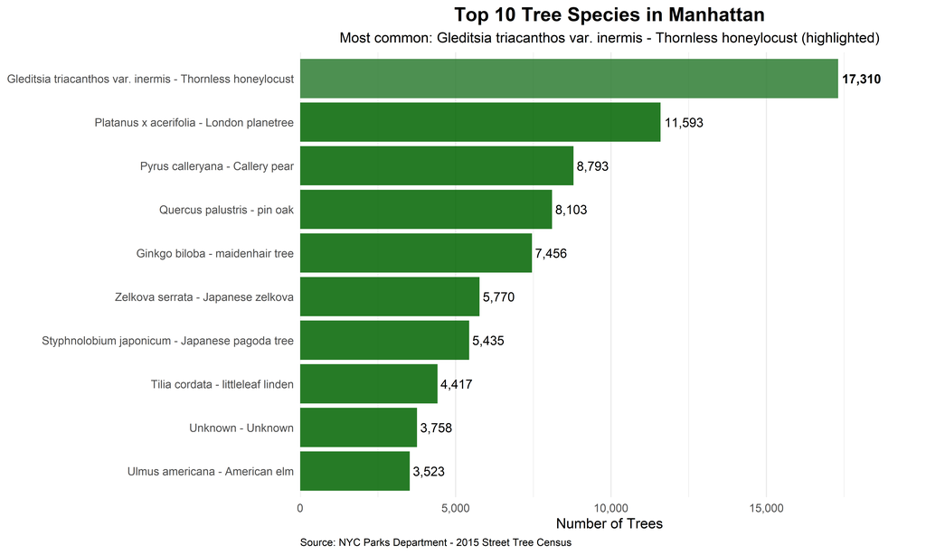

```r
MAN_SPECIES_COUNT <- TREE_DIST |>
  st_drop_geometry() |>
  filter(borough == "Manhattan") |>
  count(genusspecies, sort = TRUE) |>
  slice_head(n = 10)

COMMON_MANHATTAN_TREE <- MAN_SPECIES_COUNT |> slice(1)
top_species <- COMMON_MANHATTAN_TREE$genusspecies

# Visualization
ggplot(MAN_SPECIES_COUNT, aes(x = reorder(genusspecies, n), y = n)) +
  geom_col(aes(fill = genusspecies == top_species), alpha = 0.85) +
  scale_fill_manual(values = c("FALSE" = "darkgreen", "TRUE" = "#2E7D32")) +
  geom_text(
    aes(label = comma(n),
        fontface = ifelse(genusspecies == top_species, "bold", "plain")),
    hjust = -0.1, size = 3.5
  ) +
  coord_flip() +
  scale_y_continuous(expand = expansion(mult = c(0, 0.15)), labels = comma) +
  labs(
    title = "Top 10 Tree Species in Manhattan",
    subtitle = sprintf("Most common: %s (highlighted)", top_species),
    x = NULL,
    y = "Number of Trees",
    caption = "Source: NYC Parks Department - 2015 Street Tree Census"
  ) +
  theme_minimal() +
  theme(
    plot.title = element_text(hjust = 0.5, size = 15, face = "bold"),
    plot.subtitle = element_text(hjust = 0.5, size = 11),
    plot.caption = element_text(hjust = 0, size = 8),
    legend.position = "none",
    panel.grid.major.y = element_blank()
  )
```

**Finding:** The most common tree species in Manhattan is **Gleditsia triacanthos var. inermis - Thornless honeylocust** with **17,310** trees.

Manhattan’s species composition reflects intentional urban forestry choices favoring trees that tolerate harsh urban conditions including limited soil volume, air pollution, reflected heat from buildings, and salt exposure. The dominance of certain species also raises questions about biodiversity and resilience to species-specific pests or diseases.

## Q5: Closest Tree to Baruch College

```r
# Baruch College location
baruch_point <- new_st_point(lat = 40.7403, lon = -73.9830)

# Find closest tree
TREE_DIST_WGS <- TREE_DIST |> st_transform(crs = "WGS84")

CLOSEST_TREE <- TREE_DIST_WGS |>
  mutate(distance_m = as.numeric(st_distance(geometry, baruch_point))) |>
  arrange(distance_m) |>
  slice(1)

# Display info
closest_info <- CLOSEST_TREE |>
  st_drop_geometry() |>
  select(
    Species = genusspecies,
    Condition = tpcondition,
    District = CounDist,
    Borough = borough,
    `Distance (m)` = distance_m
  ) |>
  mutate(`Distance (m)` = round(`Distance (m)`, 1))

kable(closest_info, caption = "Closest Tree to Baruch College (25th St & Lexington Ave)")
```

Closest Tree to Baruch College (25th St & Lexington Ave)

|  | Species | Condition | District | Borough | Distance (m) |
| --- | --- | --- | --- | --- | --- |
| 167719 | Pyrus calleryana - Callery pear | Fair | 2 | Manhattan | 8.5 |

**Finding:** The nearest tree to Baruch College is a **Pyrus calleryana - Callery pear**, located approximately **8.5** meters (27.9 feet) away.

This hyperlocal analysis demonstrates the precision of the tree census data and highlights the immediate urban forest resources available to the Baruch community. Street trees in the Murray Hill/Gramercy neighborhood provide shade, air quality improvements, and aesthetic benefits to students, faculty, and staff throughout the academic year.

# Conclusion

## Key Findings

This spatial analysis of NYC’s street tree inventory reveals important patterns in urban forest distribution:

1. **Geographic Inequality**: Outer borough districts generally have higher absolute tree counts, while density measures reveal more nuanced patterns of tree coverage.
2. **Maintenance Challenges**: Several districts show elevated dead tree percentages exceeding 5%, indicating need for enhanced tree care programs and replacement initiatives.
3. **Species Concentration**: Manhattan’s tree composition is dominated by a small number of hardy species adapted to dense urban conditions, with potential implications for ecosystem resilience.
4. **Hyperlocal Precision**: The street tree census enables analysis at multiple scales from citywide patterns to individual tree identification.

## Implications for Urban Planning

These findings have several policy implications:

- **Environmental Justice**: Tree density disparities may reflect broader patterns of environmental inequality requiring targeted intervention in underserved districts
- **Tree Care Resources**: Districts with high dead tree percentages need increased maintenance budgets and expedited replacement programs
- **Species Diversity**: Future planting initiatives should prioritize biodiversity to reduce vulnerability to species-specific threats
- **Data-Driven Management**: The street tree census enables evidence-based urban forestry planning and resource allocation

## Future Research

Additional analyses could examine:

- Temporal changes by comparing 2015 census data with previous surveys
- Correlation between tree coverage and heat vulnerability indices
- Relationship between tree density and property values
- Impact of tree coverage on local air quality measurements
- Analysis of tree species by growing conditions (sidewalk width, soil volume, building height)

*This analysis was conducted as part of STA 9750 at Baruch College, Fall 2025.*